# Investigation of the most important features of a property for predicting sale price.

## by Ben Farrell

## Date: 15/05/2020

## Investigation Overview

> The aim of this investigation was to produce useful visualisations and insights into features of a property which provide a useful basis upon which to predict Sale Price.

## Dataset Overview

> The data set consists of information regarding 1460 properties sold in Ames Iowa, with 79 explanatory variables describing (almost) every aspect of residence.

> The dataset can be found on: [Kaggle](https://www.kaggle.com/c/house-prices-advanced-regression-techniques/data)

> Feature documentation available: [Ames Housing Data](http://web.stanford.edu/class/stats191/data/amesdoc.txt).

## Distribution of SalePrice

> A simple distribution of SalePrice will reveal a right skew which doesn't follow a normal distribution. However, if the SalePrice is transformed using a Logarithmic Transformation, the distribution is much closer to a normal distribution.

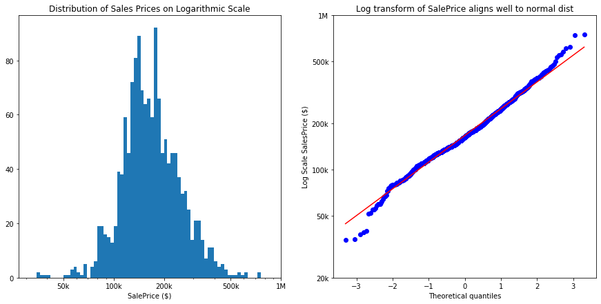

```python
plt.figure(figsize=[15, 7])

plt.subplot(121)
plt.hist(data = df, x = 'SalePrice', bins = bins)
plt.xscale('log')
plt.xticks([5e4, 1e5, 2e5, 5e5, 1e6], ['50k','100k', '200k', '500k', '1M'])
plt.xlabel('SalePrice ($)')
plt.title('Distribution of Sales Prices on Logarithmic Scale');

plt.subplot(122)
res = stats.probplot(df['LogTransSalePrice'],plot=plt)
plt.ylabel('Log Scale SalesPrice ($)')
plt.yticks([4.3, 4.7, 5.0, 5.3, 5.7, 6.0],['20k','50k','100k','200k','500k','1M'])
plt.title('Log transform of SalePrice aligns well to normal dist');
```

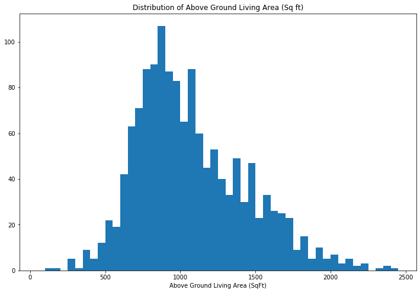

```python
plt.figure(figsize=[12,8])
binsize = 50
bins = np.arange(50,2500,binsize)
plt.hist(df['TotalBsmtSF'],bins=bins)
plt.xlabel('Above Ground Living Area (SqFt)')
plt.title('Distribution of Above Ground Living Area (Sq ft)');
```

## Construction Rate over Observation Period

> House Building had two small spikes in the early 70s and mid 70s. There is a gradual rise is house building from the early 90s to millenium. From early 2000s there was a real boom in house building unitl 2008. This aligns with the financial crash and and era of recession which explains the sharp fall in house building.

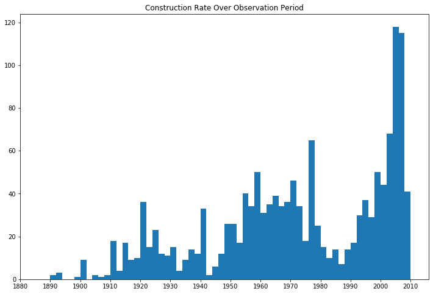

```python
plt.figure(figsize=[12,8])
bins = np.arange(1890,2011,2)
plt.hist(df['YearBuilt'],bins=bins)
plt.xticks(np.arange(1880,2011,10))
plt.title('Construction Rate Over Observation Period');
```

## Build Quality is a good indicator of SalesPrice

> In terms of categorical variables, Overall Quality (ordinal) had the strongest correlation with logarithmic SalePrice. Once again this is intuitive, as it is common to pay proportionally more for higher quality.

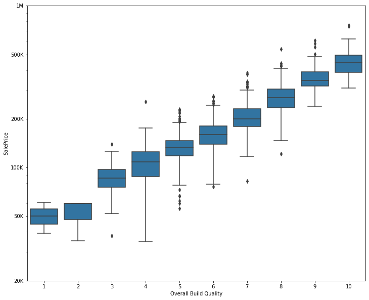

```python
#Set seaborn colour palette to base
base = sns.color_palette()[0]
plt.figure(figsize=(12,10))
sns.boxplot(data = df, x = 'OverallQual', y = 'SalePrice', color = base)
plt.xlabel('Overall Build Quality')
plt.yscale('log')
plt.yticks([2e4,5e4,1e5,2e5,5e5,1e6],['20K','50K','100K','200K','500K','1M']);
```

## Vinyl material is associated with Higher Overall Quaity Rating

> In the lowest quality properties (Less than 5), wood and metal are the most popular building materials.

> In the mediocre properties (Between 5-6), wood is by far the most common build material. Then in the higher quality properties (7 and above) vinyl is the most common build material.

> Very few properties are rated less than 3 and more than 8, so there is a lack of data in these ranges.

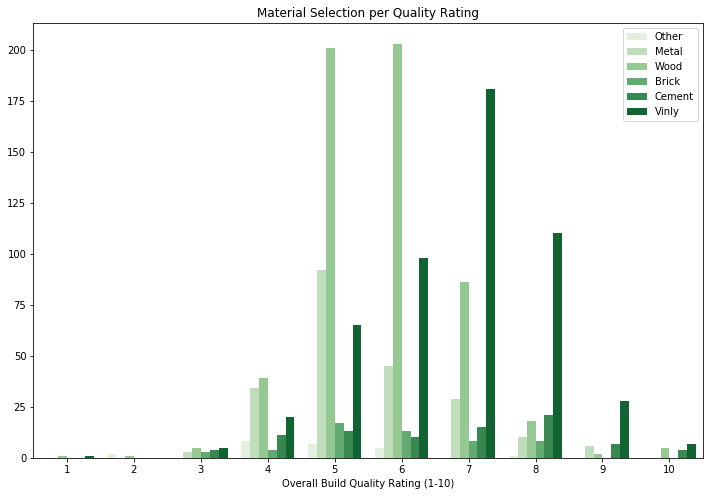

```python
plt.figure(figsize=[12,8])
sns.countplot(data = df, x = 'OverallQual', hue = 'Ext', palette = 'Greens')
plt.title('Material Selection per Quality Rating')
plt.ylabel('')
plt.xlabel('Overall Build Quality Rating (1-10)')
plt.legend(loc=1);
```

## There is a strong postive correlation between Liveable Area Above Grade and SalePrice

> The investigation found strong a positive correlation between logarithmic SalePrice and GrdLivArea (available living area in the property above grade).

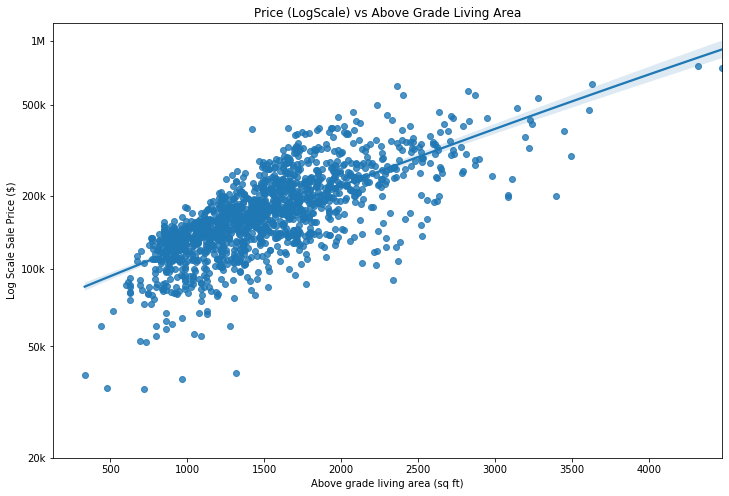

```python
plt.figure(figsize=[12,8])
sns.regplot(data=df,x='GrLivArea',y='LogTransSalePrice')
#plt.scatter(df['GrLivArea'],df['SalePrice'])
plt.yscale('log')
#plt.yticks([2e4,5e4,1e5,2e5,5e5,1e6],['20K','50K','100K','200K','500K','1M'])
plt.yticks([4.3, 4.7, 5.0, 5.3, 5.7, 6.0],['20k','50k','100k','200k','500k','1M'])
plt.title('Price (LogScale) vs Above Grade Living Area');
plt.xlabel('Above grade living area (sq ft)')
plt.ylabel('Log Scale Sale Price ($)');
```

## The Combination of a Large Living Area and High Build Quality Demands a High Selling Price

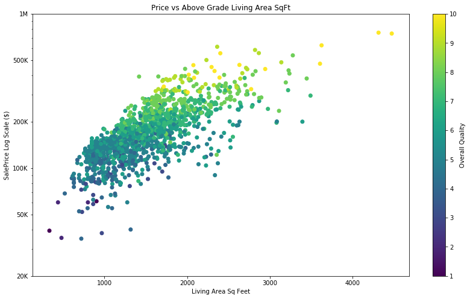

```python
plt.figure(figsize=[14,8])
scat = plt.scatter(data = df, x = 'GrLivArea', y = 'SalePrice', c = 'OverallQual')
plt.yscale('log')
plt.yticks([2e4,5e4,1e5,2e5,5e5,1e6],['20K','50K','100K','200K','500K','1M'])
plt.title('Price vs Above Grade Living Area SqFt')
plt.ylabel('SalePrice Log Scale ($)')
plt.xlabel('Living Area Sq Feet')
cbar = plt.colorbar(scat)
cbar.set_label('Overall Quality');
```

## Neighbourhood also plays an import factor in property price

> The dataset consisted of 25 Neighbourhoods. The price of homes did vary considerably in some neighbourhoods, but there was certainly a correlation between neighbourhood and house price. Some neighbourhoods only contained properties at the lower end of the price scale, such as Meadow Village, whilst others contained a substantial percentage in the upper price band, such as Northridge.

> The below scatter plot outlines five neighbourhoods in the dataset:
> - Meadow Village - Low Rank
> - Iowa DOT and Rail Road - Low Rank
> - Mitchell - Mid Rank
> - NorthRidge - High Rank
> - NorthRidge Heights - High Rank

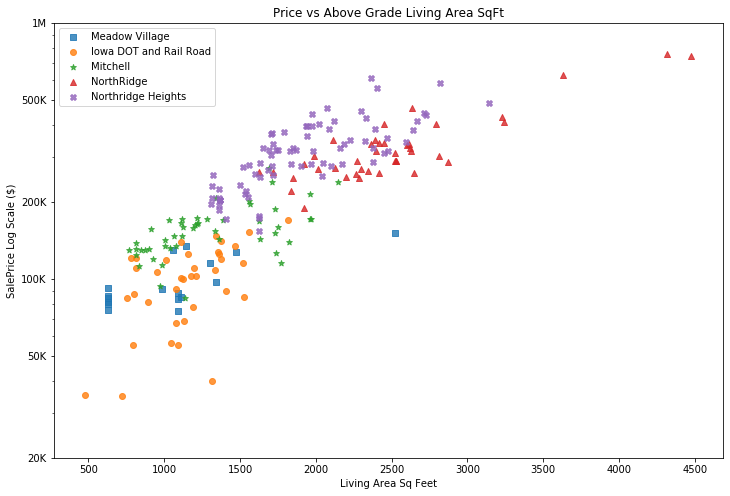

```python
#Review Price vs Living Area (Hue: Neighbourhood)
plt.figure(figsize=[12,8])
for mat, marker in ttype_markers:
    plot_data = df.loc[df['Neighborhood']==mat]
    sns.regplot(data=plot_data, x='GrLivArea', y='SalePrice', x_jitter=0.05,
            fit_reg= False, marker = marker, label=abbr_marker[mat])

plt.yscale('log')
plt.yticks([2e4,5e4,1e5,2e5,5e5,1e6],['20K','50K','100K','200K','500K','1M'])
plt.title('Price vs Above Grade Living Area SqFt')
plt.ylabel('SalePrice Log Scale ($)')
plt.xlabel('Living Area Sq Feet')
plt.legend(loc='best')
plt.show()
```